# `Boot`: Bootstrapping for regression models

#### References

Davison, A, and Hinkley, D. (1997) Bootstrap Methods and their Applications. Oxford: Oxford University Press. Fox, J. and Weisberg, S. (2019) Companion to Applied Regression, Third Edition. Thousand Oaks: Sage. * Fox, J. and Weisberg, S. (2017) Bootstrapping, http://socserv.mcmaster.ca/jfox/Books/Companion/ appendix/Appendix-Bootstrapping.pdf. * Weisberg, S. (2014) Applied Linear Regression, Fourth Edition, Wiley Wiley, Chapters 4 and 11. See Also Functions that work with boot objects from the boot package are boot.array, boot.ci, plot.boot and empinf. Additional functions in the car package are summary.boot, confint.boot, and hist.boot.

#### Examples

```r
m1 <- lm(Fertility ~ ., swiss)
betahat.boot <- Boot(m1, R=199) # 199 bootstrap samples--too small to be useful
summary(betahat.boot) # default summary
```

```
##
## Number of bootstrap replications R = 199
##                  original   bootBias    bootSE  bootMed
## (Intercept)      66.91518 -0.2265581 11.607646 66.54308
## Agriculture      -0.17211 -0.0057215  0.061333 -0.18219
## Examination      -0.25801 -0.0065270  0.266698 -0.30713
## Education        -0.87094 -0.0165665  0.207860 -0.89838
## Catholic          0.10412 -0.0037434  0.028156  0.10106
## Infant.Mortality  1.07705  0.0454262  0.455790  1.12019
```

```r
confint(betahat.boot)
```

```
## Bootstrap bca confidence intervals
##
##                        2.5 %      97.5 %
## (Intercept)      42.56228204 90.79372964
## Agriculture      -0.28949190 -0.02946278
## Examination      -0.63416068  0.51154422
## Education        -1.23035895 -0.36463816
## Catholic          0.04700626  0.16088862
## Infant.Mortality -0.11864551  1.93647326
```

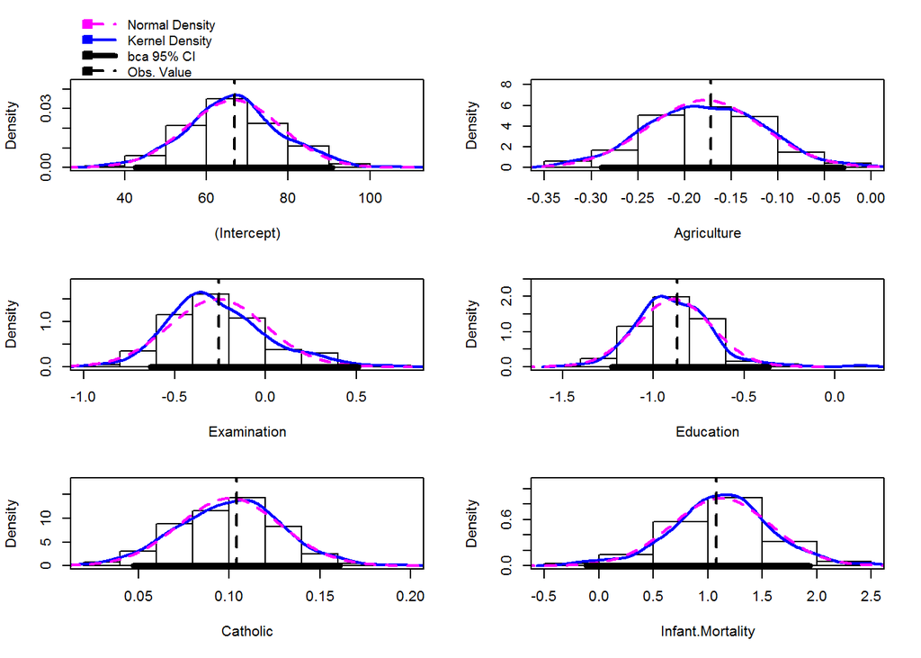

```r
hist(betahat.boot)
```

```r
# Bootstrap for the estimated residual standard deviation:
sigmahat.boot <- Boot(m1, R=199, f=sigmaHat, labels="sigmaHat")
summary(sigmahat.boot)
```

```
##            R original bootBias bootSE bootMed
## sigmaHat 199   7.1654  -0.6583 0.7316  6.4734
```

```r
confint(sigmahat.boot)
```

```
## Bootstrap bca confidence intervals
##
##             2.5 %   97.5 %
## sigmaHat 6.431332 8.462412
```